# Проектное задание_ML

## Проектное задание по машинному обучению

### «Разработка и исследование ML-модели для решения прикладной задачи»

**Делали:** Ченцов Егор, Калмыков Амирхан  
**Группа:** ИД24-3

#### Цель

Разработать и обосновать модель машинного обучения для решения реальной прикладной задачи в любой предметной области с полным циклом: данные → модель → оценка → интерпретация → сохранение модели.

#### Область

● Бизнес / маркетинг (churn, сегментация, рекомендации)

## Этапы проекта

### 3.1 Постановка задачи

**Бизнес-задача:**  
Разработка системы прогнозирования оттока клиентов для телекоммуникационной компании

В условиях высокой конкуренции на рынке телеком-услуг удержание текущих клиентов становится более приоритетной задачей, чем привлечение новых. Данный проект направлен на **создание ML-модели**, способной выявлять клиентов с высоким риском расторжения контракта на ранней стадии.

**Бизнес-цель** Минимизировать финансовые потери (Churn Loss) за счёт своевременного предложения персонализированных условий. Мы решаем задачу бинарной классификации, где целевая переменная — факт ухода клиента в текущем квартале.

### 3.2 Данные

Используется датасет **Telco Customer Churn** от IBM.

- 7043 наблюдения, 33 признака.
- Целевая переменная: `Churn Value` (или `Churn Label`).
- Признаки: демографические (пол, возраст, наличие партнёра, иждивенцев), поведенческие (длительность обслуживания, услуги), договорные (тип контракта, способ оплаты), финансовые (ежемесячные и общие платежи).

### 3.3 Предобработка

#### установка библиотеки

```python
!pip install kagglehub
```

#### используемые библиотеки

```python
import pandas as pd
import numpy as np
import seaborn as sns
import matplotlib.pyplot as plt
import plotly.express as px
import scipy.stats as stats
import statsmodels.api as sm

from sklearn.model_selection import train_test_split, GridSearchCV
from sklearn.preprocessing import StandardScaler
from sklearn.linear_model import LogisticRegression
from sklearn.tree import DecisionTreeClassifier
from sklearn.ensemble import RandomForestClassifier, GradientBoostingClassifier
from sklearn.metrics import accuracy_score, precision_score, recall_score, f1_score, roc_auc_score, classification_report, roc_curve, auc
import joblib

%matplotlib inline
sns.set_style('whitegrid')
```

**Источники датасета**  
https://community.ibm.com/community/user/blogs/steven-macko/2019/07/11/telco-customer-churn-1113  
https://www.kaggle.com/datasets/blastchar/telco-customer-churn

```python
import kagglehub

path = kagglehub.dataset_download("yeanzc/telco-customer-churn-ibm-dataset")
print("Путь:", path)
```

```
Путь: C:\Users\Home\.cache\kagglehub\datasets\yeanzc\telco-customer-churn-ibm-dataset\versions\1
```

```python
#df = pd.read_csv(f"{path}/WA_Fn-UseC_-Telco-Customer-Churn.csv")
db = pd.read_excel(f"{path}/Telco_customer_churn.xlsx")
db_raw = db.copy()
```

```python
print("Размер данных:", db.shape)
```

```
Размер данных: (7043, 33)
```

```python
db.head()
```

|  | CustomerID | Count | Country | State | City | Zip Code | Lat Long | Latitude | Longitude | Gender | ... | Contract | Paperless Billing | Payment Method | Monthly Charges | Total Charges | Churn Label | Churn Value | Churn Score | CLTV | Churn Reason |
| --- | --- | --- | --- | --- | --- | --- | --- | --- | --- | --- | --- | --- | --- | --- | --- | --- | --- | --- | --- | --- | --- |
| 0 | 3668-QPYBK | 1 | United States | California | Los Angeles | 90003 | 33.964131, -118.272783 | 33.964131 | -118.272783 | Male | ... | Month-to-month | Yes | Mailed check | 53.85 | 108.15 | Yes | 1 | 86 | 3239 | Competitor made better offer |
| 1 | 9237-HQITU | 1 | United States | California | Los Angeles | 90005 | 34.059281, -118.30742 | 34.059281 | -118.307420 | Female | ... | Month-to-month | Yes | Electronic check | 70.70 | 151.65 | Yes | 1 | 67 | 2701 | Moved |
| 2 | 9305-CDSKC | 1 | United States | California | Los Angeles | 90006 | 34.048013, -118.293953 | 34.048013 | -118.293953 | Female | ... | Month-to-month | Yes | Electronic check | 99.65 | 820.5 | Yes | 1 | 86 | 5372 | Moved |
| 3 | 7892-POOKP | 1 | United States | California | Los Angeles | 90010 | 34.062125, -118.315709 | 34.062125 | -118.315709 | Female | ... | Month-to-month | Yes | Electronic check | 104.80 | 3046.05 | Yes | 1 | 84 | 5003 | Moved |
| 4 | 0280-XJGEX | 1 | United States | California | Los Angeles | 90015 | 34.039224, -118.266293 | 34.039224 | -118.266293 | Male | ... | Month-to-month | Yes | Bank transfer (automatic) | 103.70 | 5036.3 | Yes | 1 | 89 | 5340 | Competitor had better devices |

5 rows × 33 columns

```python
db.info()
```

```
<class 'pandas.core.frame.DataFrame'>
RangeIndex: 7043 entries, 0 to 7042
Data columns (total 33 columns):
 #   Column             Non-Null Count  Dtype
---  ------             --------------  -----
 0   CustomerID         7043 non-null   object
 1   Count              7043 non-null   int64
 2   Country            7043 non-null   object
 3   State              7043 non-null   object
 4   City               7043 non-null   object
 5   Zip Code           7043 non-null   int64
 6   Lat Long           7043 non-null   object
 7   Latitude           7043 non-null   float64
 8   Longitude          7043 non-null   float64
 9   Gender             7043 non-null   object
```

[output cut: 25 more lines]

Преобразуем Total Charges в число, пропуски заполним медианой

```python
db['Total Charges'] = pd.to_numeric(db['Total Charges'], errors='coerce')
db['Total Charges'] = db['Total Charges'].fillna(db['Total Charges'].median())
```

Создаем новый признак: количество подключенных дополнительных услуг

```python
services = ['Phone Service', 'Multiple Lines', 'Internet Service',
            'Online Security', 'Online Backup', 'Device Protection',
            'Tech Support', 'Streaming TV', 'Streaming Movies']
```

Считаем количество услуг и отношение ежемесячного платежа к общему

```python
db['Total Services'] = db[services].apply(lambda x: x.str.contains('Yes').sum(), axis=1)
db['Charges Ratio'] = db['Monthly Charges'] / (db['Total Charges'] + 1)
```

**Для повышения предсказательной способности модели** был введен признак Charges Ratio (отношение текущего платежа к общему), который служит индикатором интенсивности потребления услуг относительно срока лояльности. Также был создан агрегированный признак Total Services, отражающий степень вовлеченности клиента в экосистему компании (количество подключенных дополнительных опций)

Удалили неинформативные столбцы

```python
drop_cols = ['CustomerID', 'Count', 'Country', 'State', 'City', 'Zip Code',
             'Lat Long', 'Latitude', 'Longitude', 'Churn Reason']
db.drop(columns=drop_cols, inplace=True)
```

Кодирование категориальных признаков

```python
categorical_cols = db.select_dtypes(include=['object']).columns
for col in categorical_cols:
    db[col] = db[col].astype('category').cat.codes
```

Масштабирование числовых признаков (кроме целевой)

```python
num_cols = db.select_dtypes(include=['int64', 'float64']).columns.drop('Churn Value')
scaler = StandardScaler()
db[num_cols] = scaler.fit_transform(db[num_cols])
```

```python
print("Размер данных после предобработки:", db.shape)
```

```
Размер данных после предобработки: (7043, 25)
```

```python
print(f"Всего клиентов: {len(db)}")
print(f"Ушедших: {(db['Churn Value'] == 1).sum()} ({(db['Churn Value'] == 1).mean()*100:.1f}%)")
print(f"Оставшихся: {(db['Churn Value'] == 0).sum()} ({(db['Churn Value'] == 0).mean()*100:.1f}%)")
```

```
Всего клиентов: 7043
Ушедших: 1869 (26.5%)
Оставшихся: 5174 (73.5%)
```

### 3.4 EDA

#### Распределение целевой переменной

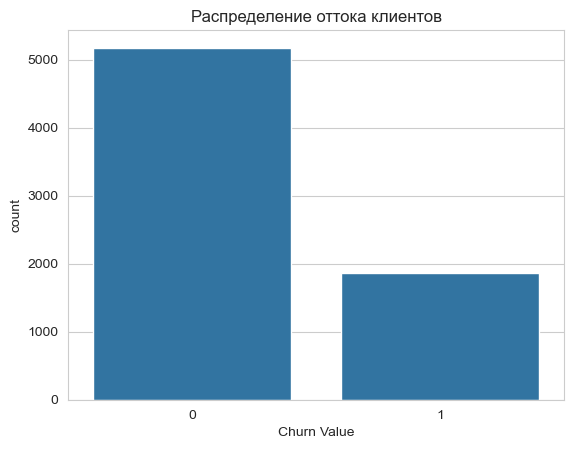

```python
sns.countplot(data=db, x='Churn Value')
plt.title('Распределение оттока клиентов')
plt.show()
```

```python
print(db['Churn Value'].value_counts(normalize=True))
```

```
Churn Value
0    0.73463
1    0.26537
Name: proportion, dtype: float64
```

Вывод: Доля оттока составляет около 26.5% – классы несбалансированы, но не критично

#### Причины оттока

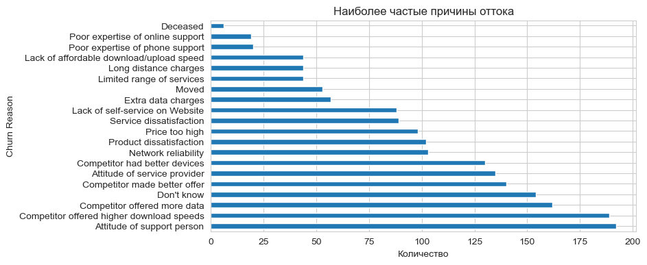

```python
churn_reason_counts = db_raw['Churn Reason'].dropna().value_counts()
plt.figure(figsize=(8,4))
churn_reason_counts.plot(kind='barh')
plt.title('Наиболее частые причины оттока')
plt.xlabel('Количество')
plt.show()
```

**Вывод:** Главные причины – отношение сотрудника поддержки, предложения конкурентов, скорость интернета, недостаток данных, цены

#### Карта корреляций

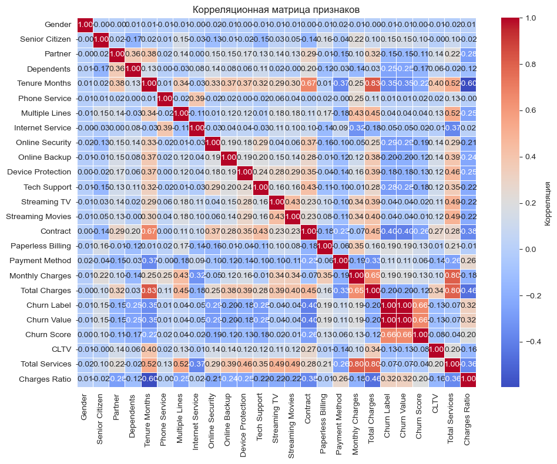

```python
plt.figure(figsize=(10, 8))
corr_matrix = db.corr(numeric_only=True)
sns.heatmap(corr_matrix, annot=True, cmap='coolwarm', fmt='.2f', linewidths=0.5, cbar_kws={'label': 'Корреляция'})
plt.title('Корреляционная матрица признаков')
plt.tight_layout()
plt.show()
```

**Выводы:**

- Tenure Months сильно коррелирует с Total Charges (0.83) и Contract (0.67).
- Churn Value отрицательно коррелирует с Tenure Months (-0.35) и Contract (-0.4).

#### Зависимость оттока от типа контракта

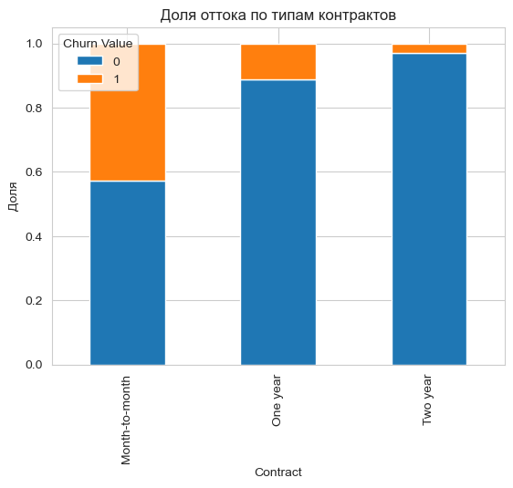

```python
contract_churn = pd.crosstab(db_raw['Contract'], db_raw['Churn Value'], normalize='index')
contract_churn.plot(kind='bar', stacked=True)
plt.title('Доля оттока по типам контрактов')
plt.ylabel('Доля')
plt.show()
```

**Вывод:** У клиентов с помесячным контрактом отток ≈45%, у годовых – ≈11%, у двухлетних – ≈3%. Долгосрочные контракты значительно снижают отток

#### Анализ tenure для ушедших клиентов

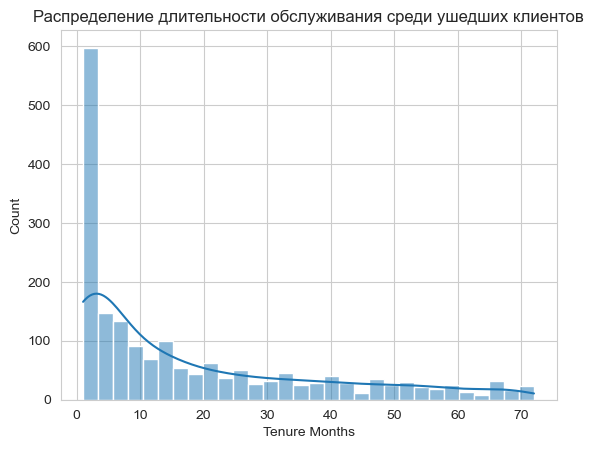

```python
churned = db_raw[db_raw['Churn Value'] == 1]
sns.histplot(churned['Tenure Months'], bins=30, kde=True)
plt.title('Распределение длительности обслуживания среди ушедших клиентов')
plt.show()
```

```python
print("Средний tenure ушедших:", churned['Tenure Months'].mean())
print("Наиболее частый tenure ушедших:", churned['Tenure Months'].mode()[0])
```

```
Средний tenure ушедших: 17.979133226324237
Наиболее частый tenure ушедших: 1
```

**Вывод:** Многие клиенты уходят в первый месяц, средний tenure ушедших ≈18 месяцев, что говорит о потерях ценных клиентов после определённого периода

```python
print(f"Класс несбалансирован: {(db['Churn Value'].value_counts()[1] / len(db) * 100):.1f}% оттока (класс 1)")
print(f"Наибольшая корреляция с оттоком: {corr_matrix['Churn Value'].drop('Churn Value').abs().sort_values(ascending=False).head(3).to_dict()}")
```

```
Класс несбалансирован: 26.5% оттока (класс 1)
Наибольшая корреляция с оттоком: {'Churn Label': 1.0, 'Churn Score': 0.6648970311816242, 'Contract': 0.396712629209845}
```

**Анализ распределения признаков показал**, что наиболее критическим периодом для удержания является первый месяц обслуживания (High Early Churn). При этом выявлена статистически значимая связь между типом контракта и вероятностью ухода: клиенты с помесячной оплатой склонны к оттоку в 15 раз чаще, чем клиенты с двухлетним контрактом. Это подтверждает необходимость фокусировки модели на поведении новых пользователей

### 3.5 Моделирование

Список столбцов, которые нужно убрать

```python
leakage_cols = ['Churn Value', 'Churn Label', 'Churn Score', 'CLTV']
```

```python
X = db.drop(columns=leakage_cols, errors='ignore')
y = db['Churn Value']

X_train, X_test, y_train, y_test = train_test_split(X, y, test_size=0.2, random_state=42, stratify=y)
```

```python
print(f"train: {X_train.shape}")
print(f"test: {X_test.shape}")
```

```
train: (5634, 21)
test: (1409, 21)
```

#### Логистическая регрессия

```python
lr = LogisticRegression(max_iter=1000, random_state=42)
lr.fit(X_train, y_train)
```

```
LogisticRegression(max_iter=1000, random_state=42)
```

```python
y_pred_lr = lr.predict(X_test)
y_proba_lr = lr.predict_proba(X_test)[:, 1]
```

#### Дерево решений

```python
dt = DecisionTreeClassifier(random_state=42, max_depth=20)
dt.fit(X_train, y_train)
```

```
DecisionTreeClassifier(max_depth=20, random_state=42)
```

```python
y_pred_dt = dt.predict(X_test)
y_proba_dt = dt.predict_proba(X_test)[:, 1]
```

#### Случайный лес

```python
rf = RandomForestClassifier(random_state=42, n_jobs=-1, n_estimators=100)
rf.fit(X_train, y_train)
```

```
RandomForestClassifier(n_jobs=-1, random_state=42)
```

```python
y_pred_rf = rf.predict(X_test)
y_proba_rf = rf.predict_proba(X_test)[:, 1]
```

#### Градиентный бустинг

```python
gb = GradientBoostingClassifier(random_state=42, n_estimators=100)
gb.fit(X_train, y_train)
```

```
GradientBoostingClassifier(random_state=42)
```

```python
y_pred_gb = gb.predict(X_test)
y_proba_gb = gb.predict_proba(X_test)[:, 1]
```

### 3.6 Оценка качества

```python
models = ['Logistic Regression', 'Decision Tree', 'Random Forest', 'Gradient Boosting']
preds = [y_pred_lr, y_pred_dt, y_pred_rf, y_pred_gb]
probas = [y_proba_lr, y_proba_dt, y_proba_rf, y_proba_gb]
```

```python
results = []
for name, pred, proba in zip(models, preds, probas):
    results.append({
        'Model': name,
        'Accuracy': accuracy_score(y_test, pred),
        'Precision': precision_score(y_test, pred),
        'Recall': recall_score(y_test, pred),
        'F1': f1_score(y_test, pred),
        'ROC-AUC': roc_auc_score(y_test, proba)
    })
```

```python
results_df = pd.DataFrame(results)
results_df
```

|  | Model | Accuracy | Precision | Recall | F1 | ROC-AUC |
| --- | --- | --- | --- | --- | --- | --- |
| 0 | Logistic Regression | 0.811214 | 0.665644 | 0.580214 | 0.620000 | 0.854998 |
| 1 | Decision Tree | 0.726757 | 0.486553 | 0.532086 | 0.508301 | 0.668237 |
| 2 | Random Forest | 0.787083 | 0.624161 | 0.497326 | 0.553571 | 0.833991 |
| 3 | Gradient Boosting | 0.814053 | 0.686667 | 0.550802 | 0.611276 | 0.854043 |

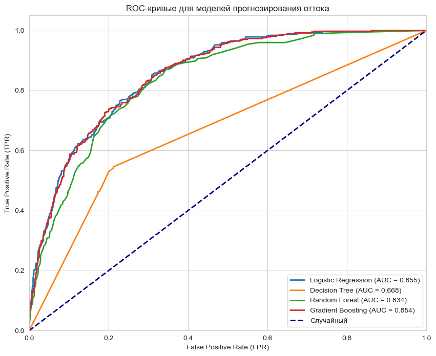

```python
plt.figure(figsize=(10, 8))

models_roc = [
    ('Logistic Regression', y_proba_lr),
    ('Decision Tree', y_proba_dt),
    ('Random Forest', y_proba_rf),
    ('Gradient Boosting', y_proba_gb)
]

for name, proba in models_roc:
    fpr, tpr, _ = roc_curve(y_test, proba)
    roc_auc = auc(fpr, tpr)
    plt.plot(fpr, tpr, lw=2, label=f'{name} (AUC = {roc_auc:.3f})')

plt.plot([0, 1], [0, 1], color='navy', lw=2, linestyle='--', label='Случайный')

plt.xlim([0.0, 1.0])
plt.ylim([0.0, 1.05])
plt.xlabel('False Positive Rate (FPR)')
plt.ylabel('True Positive Rate (TPR)')
plt.title('ROC-кривые для моделей прогнозирования оттока')
plt.legend(loc="lower right")
plt.grid(True)
plt.show()
```

### 3.7 Подбор гиперпараметров

```python
param_grid = {
    'n_estimators': [100, 200, 300],
    'max_depth': [10, 15, 20, None],
    'min_samples_split': [2, 5, 10],
    'min_samples_leaf': [1, 2, 4]
}
```

```python
rf_tune = RandomForestClassifier(random_state=42, n_jobs=-1)
grid = GridSearchCV(rf_tune, param_grid, cv=5, scoring='roc_auc', n_jobs=-1, verbose=1)
grid.fit(X_train, y_train)
```

```
Fitting 5 folds for each of 108 candidates, totalling 540 fits
```

```
GridSearchCV(cv=5, estimator=RandomForestClassifier(n_jobs=-1, random_state=42),
             n_jobs=-1,
             param_grid={'max_depth': [10, 15, 20, None],
                         'min_samples_leaf': [1, 2, 4],
                         'min_samples_split': [2, 5, 10],
                         'n_estimators': [100, 200, 300]},
             scoring='roc_auc', verbose=1)
```

```python
print(f"Лучшие параметры: {grid.best_params_}")
print(f"Лучший ROC-AUC на кросс-валидации: {grid.best_score_:.4f}")
```

```
Лучшие параметры: {'max_depth': 10, 'min_samples_leaf': 4, 'min_samples_split': 10, 'n_estimators': 300}
Лучший ROC-AUC на кросс-валидации: 0.8573
```

```python
best_rf = grid.best_estimator_
y_pred_best = best_rf.predict(X_test)
y_proba_best = best_rf.predict_proba(X_test)[:, 1]
```

```python
print(f"Accuracy:  {accuracy_score(y_test, y_pred_best):.4f}")
print(f"Precision: {precision_score(y_test, y_pred_best):.4f}")
print(f"Recall:    {recall_score(y_test, y_pred_best):.4f}")
print(f"F1-score:  {f1_score(y_test, y_pred_best):.4f}")
print(f"ROC-AUC:   {roc_auc_score(y_test, y_proba_best):.4f}")
```

```
Accuracy:  0.8084
Precision: 0.6844
Recall:    0.5160
F1-score:  0.5884
ROC-AUC:   0.8529
```

### 3.8 Интерпретация

```python
importances = best_rf.feature_importances_
features = X.columns
feat_imp = pd.Series(importances, index=features).sort_values(ascending=False)
```

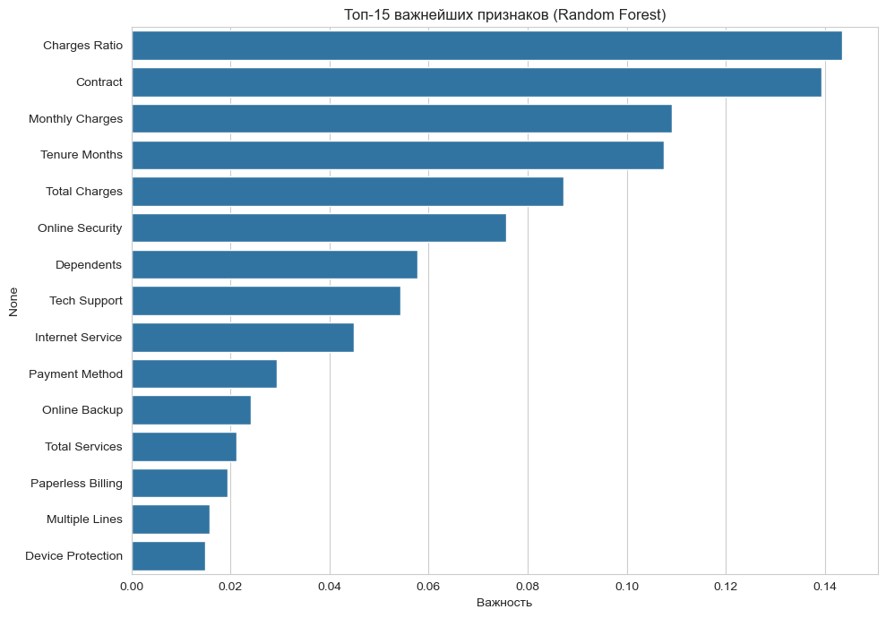

```python
plt.figure(figsize=(10, 7))
sns.barplot(x=feat_imp.values[:15], y=feat_imp.index[:15])
plt.title('Топ-15 важнейших признаков (Random Forest)')
plt.xlabel('Важность')
plt.tight_layout()
plt.show()
```

```python
print("Топ-10 признаков:")
print(feat_imp.head(10))
```

```
Топ-10 признаков:
Charges Ratio       0.143545
Contract            0.139405
Monthly Charges     0.109088
Tenure Months       0.107584
Total Charges       0.087299
Online Security     0.075690
Dependents          0.057820
Tech Support        0.054379
Internet Service    0.044941
Payment Method      0.029333
dtype: float64
```

- **Самым важным признаком оказался созданный нами Charges Ratio**. Это подтверждает гипотезу о том, что отношение текущих трат к общей накопленной сумме (по сути, интенсивность трат клиента) — критический фактор оттока
- Высокая важность признаков Contract и Tenure Months говорит о том, что клиенты на долгосрочных контрактах и те, **кто с компанией давно, уходят значительно реже**
- Monthly Charges входит в топ-3, **чем выше ежемесячный чек, тем выше риск,** что клиент найдет более дешевое предложение у конкурентов

```python
coeffs = pd.Series(lr.coef_[0], index=X.columns).sort_values()
```

[figure not shown]

```python
plt.figure(figsize=(8, 5))
coeffs.tail(15).plot(kind='barh', color='salmon')
plt.title('15 признаков, увеличивающих риск оттока', fontsize=14)
plt.xlabel('Коэффициент')
plt.tight_layout()
plt.show()
```

- **Monthly Charges** имеет самый длинный столбец вправо — это значит, чем выше платеж, тем выше риск оттока. (Гипотеза подтверждена).
- **Online Backup и Total Charges** уходят влево (отрицательный коэффициент) — это факторы, которые, наоборот, удерживают клиента.

### 3.9 Проверка гипотез

#### Гипотеза 1: Отток зависит от типа контракта

```python
df_raw = db.copy()
```

```python
cross = pd.crosstab(db_raw['Contract'], db_raw['Churn Value'])
chi2, p, dof, ex = stats.chi2_contingency(cross)
print(f'Хи-квадрат: {chi2:.2f}, p-value: {p}')
```

```
Хи-квадрат: 1184.60, p-value: 5.863038300673391e-258
```

**Вывод:** p-value < 0.001 - зависимость статистически значима

#### Гипотеза 2: Наличие техподдержки снижает отток

```python
cross_ts = pd.crosstab(df_raw['Tech Support'], df_raw['Churn Value'])
chi2_ts, p_ts, _, _ = stats.chi2_contingency(cross_ts)
print(f'Хи-квадрат: {chi2_ts:.2f}, p-value: {p_ts}')
```

```
Хи-квадрат: 828.20, p-value: 1.4430840279998987e-180
```

**Вывод:** p-value ~0.0 - техподдержка значимо связана с оттоком

### 4. Архитектура

Data → Preprocessing → Model → Evaluation → Сохранение модели

```python
joblib.dump(best_rf, 'churn_model.pkl')
joblib.dump(scaler, 'scaler.pkl')
print("Модель и скейлер сохранены.")
```

```
Модель и скейлер сохранены.
```

### Заключение

Модель готова к интеграции и сохранена в формате .pkl

```python
print('')
```